# Inbox Insights: Tracking Promotional Emails

## taking data from My Own Inbox

In this project I decided to focus in the promotional email box and I logged 56 different emails over a long period time by using google form(20 more observations were added after project2) and generate them into google sheet csv file and I also recorded the timestamp when the email arrived, the industry these email belongs, the exact number of word in each emails subject line, whether they used emojis and in this project I aim to visualise these data to see what patterns do they in my data.

here is the question format in my [survey](https://docs.google.com/forms/d/e/1FAIpQLSc6MuW0S9nTtqXggqGRNAxC4m9rIPa3A4zaSItEEPxy2rXUnA/viewform?usp=dialog)

[figure not shown]

and I collect data by whenever I received a promotion email, I will record its subject length, what kind of category it belongs to, does it contain emoji, does it mention sales or discount and also record when the email was been sent to my inbox.

## Time when the email arrives.

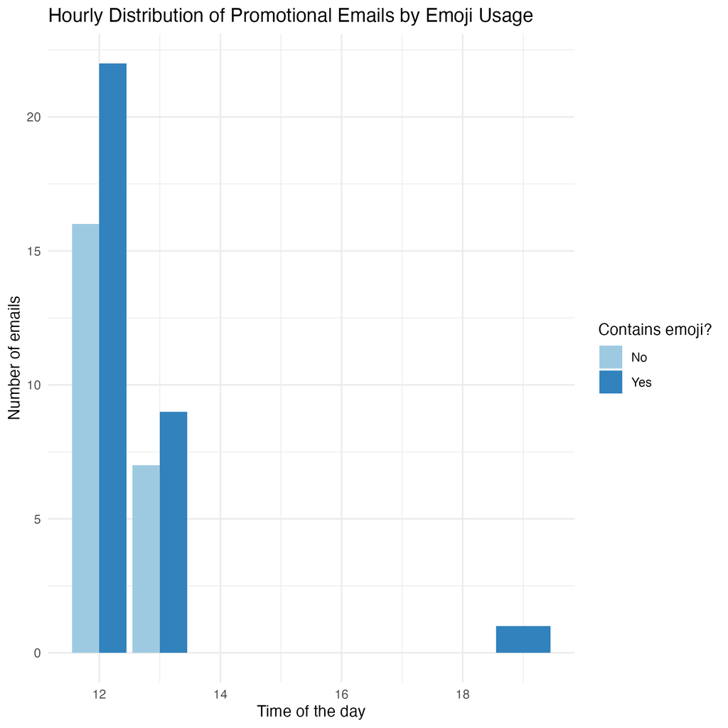

A grouped bar chart showing the number of promotional emails received at different hours of the day, split by whether they the emauls contain emojis or not.

## Which category have the longest subject length?

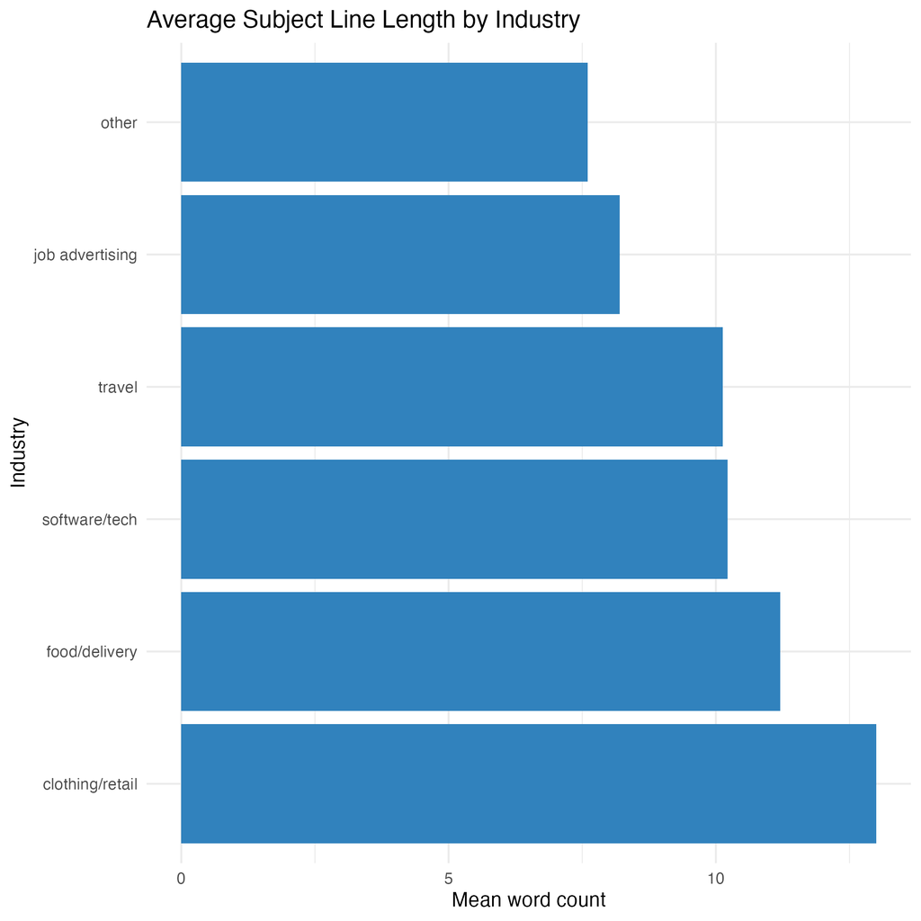

from this data we can see that the clothing/retail category is having the longest subject lines out of all the cateries which is averaging 13 words mean while food/delivery being the second longest having average of 11 words meanwhile job advetising and other emails are only having average of 8 words and less being lowest of all the category. suggest food and clothing category relys on highly descriprtive subject lines to attract viewers attention meanwhile job uses a more short and professional subject lines.

## Emojis and Subject Length plot.

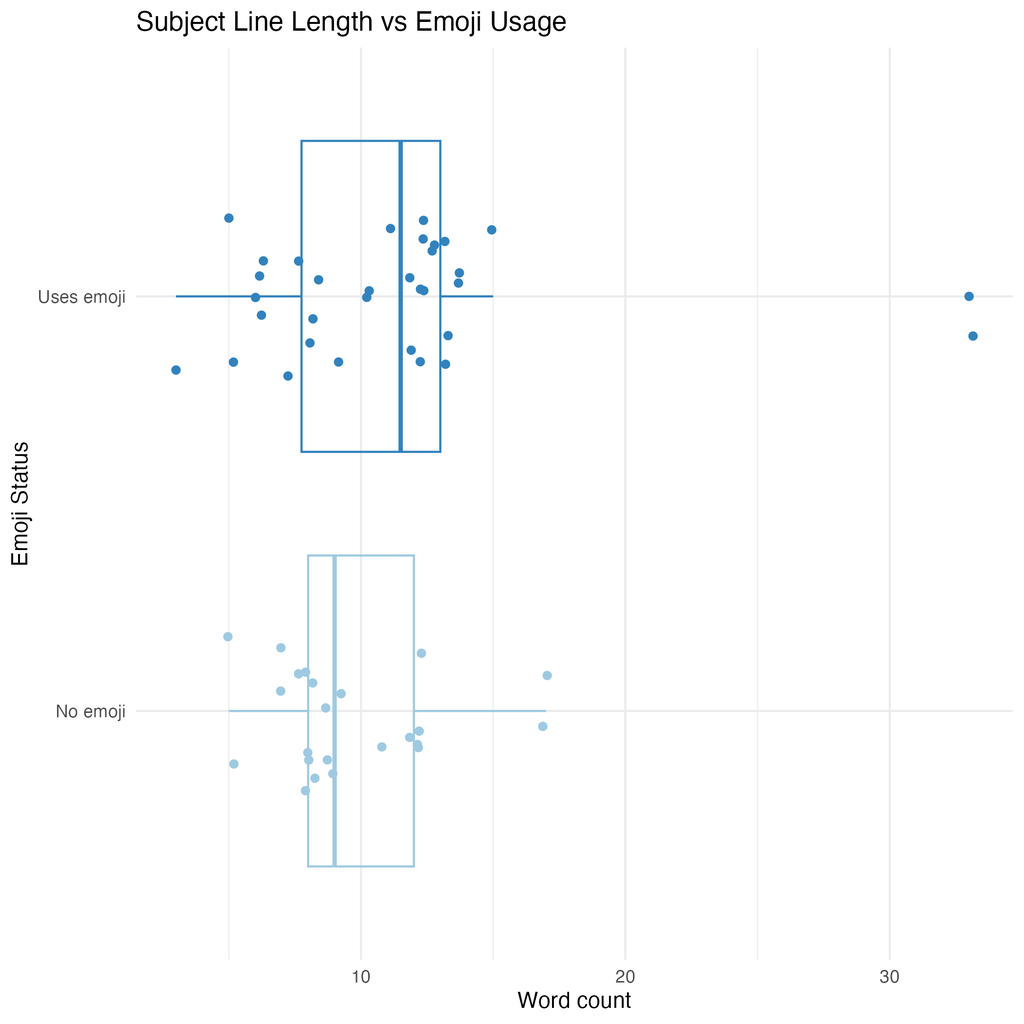

looking at the plot we can see that the median subject lines that uses emojis tends to be longer (11-12 words) than those without using emojis (9 words) the “use emoji” group has a wider spread than those who don’t use emojis which is likely due to having an outlier at around 30 words which pushes the plot to make it longer meanwhile the “no emoji” group have no outlier and more clustered compare to “use emojis” group. therefore from this graph we expect that emails that are longer tends to have an emoji in their subject lines.